# Casal2 Test Case comparisons for SBW

# 1 SBW comparison of CASAL and Casal2 model configurations

This document compares the results of at least 2 CASAL model configurations (base and at least one sensitivity) and up to 8 Casal2 model configurations (3 BetaDiff, 2 CppAD, and 3 ADOL-C).

The Casal2 ADOL-C and BetaDiff low tolerance models have a smaller tolerance value than the CASAL base model (1e-8 vs. 2e-6). The Casal2 CppAD models have a tolerance value of 1e-9.

## 1.1 SBW model characteristics

The main characteristics of the Test Case SBW (southern blue whiting) CASAL model are:

- one stock, ages 2 - 15
- two areas, spawn and nospawn
- years 1960 - 2015, projection years 2016 - 2021
- two time steps
- two stock categories, male and female
- sex-specific migration from ‘nospawn’ to ‘spawn’
- male and female natural mortality (M) average of 0.2, difference of 0.02
- Beverton-Holt stock-recruitment relationship, with steepness (h) 0.9 and $\sigma_R$ 1.0
- length-weight relationship ($W = aL^b$)
- no ageing error
- one fishery in area ‘spawn’

Observation data include:

- empirical sex-specific length-at-age data for 1979 - 2015
- survey indices for immature and mature partitions
- fishery sex-specific proportions-at-age

Parameters estimated include:

- B0
- process error for the mature survey index
- the average of and difference between male and female natural mortality
- sex-specific migration rates
- YCS (recruitment deviations)

## 1.3 CASAL and Casal2 model output

```r
source('../../R-functions/report_read_in_CASAL_MPD_files.R')
```

```r
source('../../R-functions/report_read_in_Casal2_MPD_files.R')
```

## 1.4 Tables

Tables of parameter estimates and objective function components for the CASAL and Casal2 model MPD results

CASAL parameter estimates

| rownames | Base_Model | Sensitivity_1 | Percent_Diff |
| --- | --- | --- | --- |
| initialization.B0 | 314500.00000 | 314500.00000 | 0.000 |
| relative_abundance[TangaroaAcousticMature].cv_process_error | 0.00010 | 0.00010 | 0.000 |
| natural_mortality.avg | 0.15580 | 0.15580 | 0.000 |
| natural_mortality.diff | -0.00914 | -0.00914 | 0.000 |
| migration[toSpawn].rates_male1 | 0.08558 | 0.08558 | 0.000 |
| migration[toSpawn].rates_male2 | 0.72990 | 0.72990 | 0.000 |
| migration[toSpawn].rates_male3 | 0.51270 | 0.51270 | 0.000 |
| migration[toSpawn].rates_male4 | 0.33120 | 0.33120 | 0.000 |
| migration[toSpawn].rates_male5 | 0.99000 | 0.99000 | 0.000 |
| migration[toSpawn].rates_female1 | 0.01907 | 0.01907 | 0.000 |
| migration[toSpawn].rates_female2 | 0.51250 | 0.51250 | 0.000 |
| migration[toSpawn].rates_female3 | 0.94120 | 0.94120 | 0.000 |
| migration[toSpawn].rates_female4 | 0.99900 | 0.99900 | 0.000 |
| migration[toSpawn].rates_female5 | 0.99000 | 0.99000 | 0.000 |
| recruitment.YCS1 | 0.25590 | 0.25590 | 0.000 |
| recruitment.YCS2 | 0.26100 | 0.26100 | 0.000 |
| recruitment.YCS3 | 0.26700 | 0.26700 | 0.000 |
| recruitment.YCS4 | 0.27430 | 0.27430 | 0.000 |
| recruitment.YCS5 | 0.28320 | 0.28320 | 0.000 |
| recruitment.YCS6 | 0.29410 | 0.29410 | 0.000 |
| recruitment.YCS7 | 0.30880 | 0.30880 | 0.000 |
| recruitment.YCS8 | 0.82470 | 0.82470 | 0.000 |
| recruitment.YCS9 | 0.53160 | 0.53160 | 0.000 |
| recruitment.YCS10 | 0.37070 | 0.37070 | 0.000 |
| recruitment.YCS11 | 0.26680 | 0.26680 | 0.000 |
| recruitment.YCS12 | 0.13850 | 0.13850 | 0.000 |
| recruitment.YCS13 | 0.08025 | 0.08025 | 0.000 |
| recruitment.YCS14 | 0.15820 | 0.15820 | 0.000 |
| recruitment.YCS15 | 0.10630 | 0.10630 | 0.000 |
| recruitment.YCS16 | 0.05757 | 0.05757 | 0.000 |
| recruitment.YCS17 | 0.06079 | 0.06079 | 0.000 |
| recruitment.YCS18 | 0.12720 | 0.12720 | 0.000 |
| recruitment.YCS19 | 0.05057 | 0.05057 | 0.000 |
| recruitment.YCS20 | 0.03959 | 0.03959 | 0.000 |
| recruitment.YCS21 | 0.04996 | 0.04996 | 0.000 |
| recruitment.YCS22 | 0.37590 | 0.37590 | 0.000 |
| recruitment.YCS23 | 0.36820 | 0.36820 | 0.000 |
| recruitment.YCS24 | 0.09402 | 0.09402 | 0.000 |
| recruitment.YCS25 | 0.03280 | 0.03280 | 0.000 |
| recruitment.YCS26 | 0.13650 | 0.13650 | 0.000 |
| recruitment.YCS27 | 0.13080 | 0.13080 | 0.000 |
| recruitment.YCS28 | 0.11260 | 0.11260 | 0.000 |
| recruitment.YCS29 | 0.28620 | 0.28620 | 0.000 |
| recruitment.YCS30 | 0.12790 | 0.12790 | 0.000 |
| recruitment.YCS31 | 0.43770 | 0.43770 | 0.000 |
| recruitment.YCS32 | 0.03590 | 0.03590 | 0.000 |
| recruitment.YCS33 | 0.25650 | 0.25650 | 0.000 |
| recruitment.YCS34 | 2.75100 | 2.75100 | 0.000 |
| recruitment.YCS35 | 0.55870 | 0.55870 | 0.000 |
| recruitment.YCS36 | 0.26390 | 0.26390 | 0.000 |
| recruitment.YCS37 | 0.12670 | 0.12670 | 0.000 |
| recruitment.YCS38 | 0.56000 | 0.56000 | 0.000 |
| recruitment.YCS39 | 0.36190 | 0.36190 | 0.000 |
| recruitment.YCS40 | 0.14490 | 0.14490 | 0.000 |
| recruitment.YCS41 | 0.32060 | 0.32060 | 0.000 |
| recruitment.YCS42 | 0.19280 | 0.19280 | 0.000 |
| recruitment.YCS43 | 0.29870 | 0.29870 | 0.000 |
| recruitment.YCS44 | 0.70520 | 0.70520 | 0.000 |
| recruitment.YCS45 | 0.41770 | 0.41770 | 0.000 |
| recruitment.YCS46 | 0.25430 | 0.25430 | 0.000 |
| recruitment.YCS47 | 0.25240 | 0.25240 | 0.000 |
| recruitment.YCS48 | 0.32500 | 0.32500 | 0.000 |
| recruitment.YCS49 | 1.69600 | 1.69600 | 0.000 |
| recruitment.YCS50 | 0.68660 | 0.68660 | 0.000 |
| recruitment.YCS51 | 0.20070 | 0.20070 | 0.000 |
| recruitment.YCS52 | 1.20400 | 1.20400 | 0.000 |
| recruitment.YCS53 | 0.16930 | 0.16930 | 0.000 |
| recruitment.YCS54 | 0.87570 | 0.87570 | 0.000 |
| recruitment.YCS55 | 0.13270 | 0.13270 | 0.000 |
| recruitment.YCS56 | 1.00000 | 1.00000 | 0.000 |

Casal2 parameter estimates

| rownames | betadiff_casal_flags_on | betadiff_casal_flags_off | betadiff_casal_flags_on_low_tol | cppad_casal_flags_on | cppad_casal_flags_off | adolc_casal_flags_on | adolc_casal_flags_off | adolc_casal_flags_on_low_tol |
| --- | --- | --- | --- | --- | --- | --- | --- | --- |
| process[Recruitment].b0 | 299610.00000 | 298978.00000 | 299610.00000 | 314527.00000 | 314527.00000 | 299610.00000 | 299610.00000 | 299610.00000 |
| selectivity[MaturationSel_male].v{1} | 0.08537 | 0.08529 | 0.08537 | 0.08558 | 0.08558 | 0.08537 | 0.08537 | 0.08537 |
| selectivity[MaturationSel_male].v{2} | 0.73526 | 0.73346 | 0.73526 | 0.72993 | 0.72993 | 0.73526 | 0.73526 | 0.73526 |
| selectivity[MaturationSel_male].v{3} | 0.51432 | 0.58196 | 0.51432 | 0.51267 | 0.51267 | 0.51432 | 0.51432 | 0.51432 |
| selectivity[MaturationSel_male].v{4} | 0.29398 | 0.00100 | 0.29398 | 0.33118 | 0.33118 | 0.29398 | 0.29398 | 0.29398 |
| selectivity[MaturationSel_female].v{1} | 0.01903 | 0.01901 | 0.01903 | 0.01907 | 0.01907 | 0.01903 | 0.01903 | 0.01903 |
| selectivity[MaturationSel_female].v{2} | 0.51564 | 0.51406 | 0.51564 | 0.51254 | 0.51254 | 0.51564 | 0.51564 | 0.51564 |
| selectivity[MaturationSel_female].v{3} | 0.94578 | 0.93978 | 0.94578 | 0.94120 | 0.94120 | 0.94578 | 0.94578 | 0.94578 |
| selectivity[MaturationSel_female].v{4} | 0.99900 | 0.99900 | 0.99900 | 0.99900 | 0.99900 | 0.99900 | 0.99900 | 0.99900 |
| process[Recruitment].ycs_values{1958} | 0.25169 | 0.25201 | 0.25169 | 0.25590 | 0.25590 | 0.25169 | 0.25169 | 0.25169 |
| process[Recruitment].ycs_values{1959} | 0.25626 | 0.25668 | 0.25626 | 0.26099 | 0.26099 | 0.25626 | 0.25626 | 0.25626 |
| process[Recruitment].ycs_values{1960} | 0.26170 | 0.26222 | 0.26170 | 0.26702 | 0.26702 | 0.26170 | 0.26170 | 0.26170 |
| process[Recruitment].ycs_values{1961} | 0.26830 | 0.26898 | 0.26830 | 0.27431 | 0.27431 | 0.26830 | 0.26830 | 0.26830 |
| process[Recruitment].ycs_values{1962} | 0.27632 | 0.27722 | 0.27632 | 0.28317 | 0.28317 | 0.27632 | 0.27632 | 0.27632 |
| process[Recruitment].ycs_values{1963} | 0.28636 | 0.28756 | 0.28636 | 0.29410 | 0.29410 | 0.28636 | 0.28636 | 0.28636 |
| process[Recruitment].ycs_values{1964} | 0.30009 | 0.30176 | 0.30009 | 0.30880 | 0.30880 | 0.30009 | 0.30009 | 0.30009 |
| process[Recruitment].ycs_values{1965} | 0.70701 | 0.71254 | 0.70701 | 0.82468 | 0.82468 | 0.70701 | 0.70701 | 0.70701 |
| process[Recruitment].ycs_values{1966} | 0.46402 | 0.46571 | 0.46402 | 0.53162 | 0.53162 | 0.46402 | 0.46402 | 0.46402 |
| process[Recruitment].ycs_values{1967} | 0.32237 | 0.32309 | 0.32237 | 0.37070 | 0.37070 | 0.32237 | 0.32237 | 0.32237 |
| process[Recruitment].ycs_values{1968} | 0.23172 | 0.23203 | 0.23172 | 0.26676 | 0.26676 | 0.23172 | 0.23172 | 0.23172 |
| process[Recruitment].ycs_values{1969} | 0.12143 | 0.12156 | 0.12143 | 0.13853 | 0.13853 | 0.12143 | 0.12143 | 0.12143 |
| process[Recruitment].ycs_values{1970} | 0.07084 | 0.07096 | 0.07084 | 0.08025 | 0.08025 | 0.07084 | 0.07084 | 0.07084 |
| process[Recruitment].ycs_values{1971} | 0.13612 | 0.13621 | 0.13612 | 0.15822 | 0.15822 | 0.13612 | 0.13612 | 0.13612 |
| process[Recruitment].ycs_values{1972} | 0.09151 | 0.09154 | 0.09151 | 0.10630 | 0.10630 | 0.09151 | 0.09151 | 0.09151 |
| process[Recruitment].ycs_values{1973} | 0.04983 | 0.04988 | 0.04983 | 0.05757 | 0.05757 | 0.04983 | 0.04983 | 0.04983 |
| process[Recruitment].ycs_values{1974} | 0.05215 | 0.05210 | 0.05215 | 0.06079 | 0.06079 | 0.05215 | 0.05215 | 0.05215 |
| process[Recruitment].ycs_values{1975} | 0.10750 | 0.10762 | 0.10750 | 0.12725 | 0.12725 | 0.10750 | 0.10750 | 0.10750 |
| process[Recruitment].ycs_values{1976} | 0.04308 | 0.04319 | 0.04308 | 0.05057 | 0.05057 | 0.04308 | 0.04308 | 0.04308 |
| process[Recruitment].ycs_values{1977} | 0.03373 | 0.03372 | 0.03373 | 0.03959 | 0.03959 | 0.03373 | 0.03373 | 0.03373 |
| process[Recruitment].ycs_values{1978} | 0.04227 | 0.04226 | 0.04227 | 0.04996 | 0.04996 | 0.04227 | 0.04227 | 0.04227 |
| process[Recruitment].ycs_values{1979} | 0.31277 | 0.31305 | 0.31277 | 0.37587 | 0.37587 | 0.31277 | 0.31277 | 0.31277 |
| process[Recruitment].ycs_values{1980} | 0.30480 | 0.30473 | 0.30480 | 0.36816 | 0.36816 | 0.30480 | 0.30480 | 0.30480 |
| process[Recruitment].ycs_values{1981} | 0.07799 | 0.07795 | 0.07799 | 0.09402 | 0.09402 | 0.07799 | 0.07799 | 0.07799 |
| process[Recruitment].ycs_values{1982} | 0.02751 | 0.02752 | 0.02751 | 0.03280 | 0.03280 | 0.02751 | 0.02751 | 0.02751 |
| process[Recruitment].ycs_values{1983} | 0.11248 | 0.11236 | 0.11248 | 0.13647 | 0.13647 | 0.11248 | 0.11248 | 0.11248 |
| process[Recruitment].ycs_values{1984} | 0.10757 | 0.10735 | 0.10757 | 0.13081 | 0.13081 | 0.10757 | 0.10757 | 0.10757 |
| process[Recruitment].ycs_values{1985} | 0.09256 | 0.09261 | 0.09256 | 0.11256 | 0.11256 | 0.09256 | 0.09256 | 0.09256 |
| process[Recruitment].ycs_values{1986} | 0.23474 | 0.23557 | 0.23474 | 0.28616 | 0.28616 | 0.23474 | 0.23474 | 0.23474 |
| process[Recruitment].ycs_values{1987} | 0.10518 | 0.10504 | 0.10518 | 0.12793 | 0.12793 | 0.10518 | 0.10518 | 0.10518 |
| process[Recruitment].ycs_values{1988} | 0.35849 | 0.35860 | 0.35849 | 0.43772 | 0.43772 | 0.35849 | 0.35849 | 0.35849 |
| process[Recruitment].ycs_values{1989} | 0.03001 | 0.03004 | 0.03001 | 0.03590 | 0.03590 | 0.03001 | 0.03001 | 0.03001 |
| process[Recruitment].ycs_values{1990} | 0.21160 | 0.21190 | 0.21160 | 0.25649 | 0.25649 | 0.21160 | 0.21160 | 0.21160 |
| process[Recruitment].ycs_values{1991} | 2.26862 | 2.26986 | 2.26862 | 2.75116 | 2.75116 | 2.26862 | 2.26862 | 2.26862 |
| process[Recruitment].ycs_values{1992} | 0.46042 | 0.46088 | 0.46042 | 0.55871 | 0.55871 | 0.46042 | 0.46042 | 0.46042 |
| process[Recruitment].ycs_values{1993} | 0.21818 | 0.21922 | 0.21818 | 0.26390 | 0.26390 | 0.21818 | 0.21818 | 0.21818 |
| process[Recruitment].ycs_values{1994} | 0.10632 | 0.10635 | 0.10632 | 0.12675 | 0.12675 | 0.10632 | 0.10632 | 0.10632 |
| process[Recruitment].ycs_values{1995} | 0.46220 | 0.45825 | 0.46220 | 0.56002 | 0.56002 | 0.46220 | 0.46220 | 0.46220 |
| process[Recruitment].ycs_values{1996} | 0.29958 | 0.30149 | 0.29958 | 0.36192 | 0.36192 | 0.29958 | 0.29958 | 0.29958 |
| process[Recruitment].ycs_values{1997} | 0.12096 | 0.12048 | 0.12096 | 0.14486 | 0.14486 | 0.12096 | 0.12096 | 0.12096 |
| process[Recruitment].ycs_values{1998} | 0.26476 | 0.26596 | 0.26476 | 0.32060 | 0.32060 | 0.26476 | 0.26476 | 0.26476 |
| process[Recruitment].ycs_values{1999} | 0.16048 | 0.15944 | 0.16048 | 0.19279 | 0.19279 | 0.16048 | 0.16048 | 0.16048 |
| process[Recruitment].ycs_values{2000} | 0.24624 | 0.24727 | 0.24624 | 0.29874 | 0.29874 | 0.24624 | 0.24624 | 0.24624 |
| process[Recruitment].ycs_values{2001} | 0.57498 | 0.57294 | 0.57498 | 0.70518 | 0.70518 | 0.57498 | 0.57498 | 0.57498 |
| process[Recruitment].ycs_values{2002} | 0.33816 | 0.33919 | 0.33816 | 0.41769 | 0.41769 | 0.33816 | 0.33816 | 0.33816 |
| process[Recruitment].ycs_values{2003} | 0.20585 | 0.20534 | 0.20585 | 0.25427 | 0.25427 | 0.20585 | 0.20585 | 0.20585 |
| process[Recruitment].ycs_values{2004} | 0.20174 | 0.20091 | 0.20174 | 0.25238 | 0.25238 | 0.20174 | 0.20174 | 0.20174 |
| process[Recruitment].ycs_values{2005} | 0.25678 | 0.25655 | 0.25678 | 0.32495 | 0.32495 | 0.25678 | 0.25678 | 0.25678 |
| process[Recruitment].ycs_values{2006} | 1.31409 | 1.31392 | 1.31409 | 1.69567 | 1.69567 | 1.31409 | 1.31409 | 1.31409 |
| process[Recruitment].ycs_values{2007} | 0.52328 | 0.52067 | 0.52328 | 0.68660 | 0.68660 | 0.52328 | 0.52328 | 0.52328 |
| process[Recruitment].ycs_values{2008} | 0.15242 | 0.15133 | 0.15242 | 0.20067 | 0.20067 | 0.15242 | 0.15242 | 0.15242 |
| process[Recruitment].ycs_values{2009} | 0.87606 | 0.86701 | 0.87606 | 1.20372 | 1.20372 | 0.87606 | 0.87606 | 0.87606 |
| process[Recruitment].ycs_values{2010} | 0.00772 | 0.00772 | 0.00772 | 0.16935 | 0.16935 | 0.00772 | 0.00772 | 0.00772 |
| process[Recruitment].ycs_values{2011} | 0.59070 | 0.58506 | 0.59070 | 0.87569 | 0.87569 | 0.59070 | 0.59070 | 0.59070 |
| process[Recruitment].ycs_values{2012} | 0.09495 | 0.09453 | 0.09495 | 0.13266 | 0.13266 | 0.09495 | 0.09495 | 0.09495 |
| process[Instantaneous_Mortality].m{male.nonspawn} | 0.15745 | 0.15777 | 0.15745 | 0.15118 | 0.15118 | 0.15745 | 0.15745 | 0.15745 |
| process[Instantaneous_Mortality].m{female.nonspawn} | 0.16651 | 0.16689 | 0.16651 | 0.16033 | 0.16033 | 0.16651 | 0.16651 | 0.16651 |
| observation[TangaroaAcousticMature].process_error | 0.00010 | 0.00010 | 0.00010 | 0.00010 | 0.00010 | 0.00010 | 0.00010 | 0.00010 |

Casal2 parameter estimates: Percent Difference from betadiff_casal_flags_on

| rownames | betadiff_casal_flags_on | betadiff_casal_flags_off | betadiff_casal_flags_on_low_tol | cppad_casal_flags_on | cppad_casal_flags_off | adolc_casal_flags_on | adolc_casal_flags_off | adolc_casal_flags_on_low_tol |
| --- | --- | --- | --- | --- | --- | --- | --- | --- |
| process[Recruitment].b0 | 0.000 | 0.211 | 0.000 | -4.979 | -4.979 | 0.000 | 0.000 | 0.000 |
| selectivity[MaturationSel_male].v{1} | 0.000 | 0.085 | 0.000 | -0.254 | -0.254 | 0.000 | 0.000 | 0.000 |
| selectivity[MaturationSel_male].v{2} | 0.000 | 0.244 | 0.000 | 0.725 | 0.725 | 0.000 | 0.000 | 0.000 |
| selectivity[MaturationSel_male].v{3} | 0.000 | -13.150 | 0.000 | 0.321 | 0.321 | 0.000 | 0.000 | 0.000 |
| selectivity[MaturationSel_male].v{4} | 0.000 | 99.660 | 0.000 | -12.654 | -12.654 | 0.000 | 0.000 | 0.000 |
| selectivity[MaturationSel_female].v{1} | 0.000 | 0.125 | 0.000 | -0.211 | -0.211 | 0.000 | 0.000 | 0.000 |
| selectivity[MaturationSel_female].v{2} | 0.000 | 0.305 | 0.000 | 0.601 | 0.601 | 0.000 | 0.000 | 0.000 |
| selectivity[MaturationSel_female].v{3} | 0.000 | 0.635 | 0.000 | 0.484 | 0.484 | 0.000 | 0.000 | 0.000 |
| selectivity[MaturationSel_female].v{4} | 0.000 | 0.000 | 0.000 | 0.000 | 0.000 | 0.000 | 0.000 | 0.000 |
| process[Recruitment].ycs_values{1958} | 0.000 | -0.130 | 0.000 | -1.673 | -1.673 | 0.000 | 0.000 | 0.000 |
| process[Recruitment].ycs_values{1959} | 0.000 | -0.161 | 0.000 | -1.847 | -1.847 | 0.000 | 0.000 | 0.000 |
| process[Recruitment].ycs_values{1960} | 0.000 | -0.200 | 0.000 | -2.036 | -2.036 | 0.000 | 0.000 | 0.000 |
| process[Recruitment].ycs_values{1961} | 0.000 | -0.255 | 0.000 | -2.243 | -2.243 | 0.000 | 0.000 | 0.000 |
| process[Recruitment].ycs_values{1962} | 0.000 | -0.325 | 0.000 | -2.479 | -2.479 | 0.000 | 0.000 | 0.000 |
| process[Recruitment].ycs_values{1963} | 0.000 | -0.420 | 0.000 | -2.703 | -2.703 | 0.000 | 0.000 | 0.000 |
| process[Recruitment].ycs_values{1964} | 0.000 | -0.559 | 0.000 | -2.902 | -2.902 | 0.000 | 0.000 | 0.000 |
| process[Recruitment].ycs_values{1965} | 0.000 | -0.782 | 0.000 | -16.643 | -16.643 | 0.000 | 0.000 | 0.000 |
| process[Recruitment].ycs_values{1966} | 0.000 | -0.364 | 0.000 | -14.570 | -14.570 | 0.000 | 0.000 | 0.000 |
| process[Recruitment].ycs_values{1967} | 0.000 | -0.224 | 0.000 | -14.993 | -14.993 | 0.000 | 0.000 | 0.000 |
| process[Recruitment].ycs_values{1968} | 0.000 | -0.132 | 0.000 | -15.121 | -15.121 | 0.000 | 0.000 | 0.000 |
| process[Recruitment].ycs_values{1969} | 0.000 | -0.107 | 0.000 | -14.081 | -14.081 | 0.000 | 0.000 | 0.000 |
| process[Recruitment].ycs_values{1970} | 0.000 | -0.181 | 0.000 | -13.297 | -13.297 | 0.000 | 0.000 | 0.000 |
| process[Recruitment].ycs_values{1971} | 0.000 | -0.064 | 0.000 | -16.229 | -16.229 | 0.000 | 0.000 | 0.000 |
| process[Recruitment].ycs_values{1972} | 0.000 | -0.038 | 0.000 | -16.169 | -16.169 | 0.000 | 0.000 | 0.000 |
| process[Recruitment].ycs_values{1973} | 0.000 | -0.098 | 0.000 | -15.536 | -15.536 | 0.000 | 0.000 | 0.000 |
| process[Recruitment].ycs_values{1974} | 0.000 | 0.098 | 0.000 | -16.571 | -16.571 | 0.000 | 0.000 | 0.000 |
| process[Recruitment].ycs_values{1975} | 0.000 | -0.105 | 0.000 | -18.367 | -18.367 | 0.000 | 0.000 | 0.000 |
| process[Recruitment].ycs_values{1976} | 0.000 | -0.260 | 0.000 | -17.388 | -17.388 | 0.000 | 0.000 | 0.000 |
| process[Recruitment].ycs_values{1977} | 0.000 | 0.025 | 0.000 | -17.382 | -17.382 | 0.000 | 0.000 | 0.000 |
| process[Recruitment].ycs_values{1978} | 0.000 | 0.024 | 0.000 | -18.215 | -18.215 | 0.000 | 0.000 | 0.000 |
| process[Recruitment].ycs_values{1979} | 0.000 | -0.090 | 0.000 | -20.174 | -20.174 | 0.000 | 0.000 | 0.000 |
| process[Recruitment].ycs_values{1980} | 0.000 | 0.022 | 0.000 | -20.787 | -20.787 | 0.000 | 0.000 | 0.000 |
| process[Recruitment].ycs_values{1981} | 0.000 | 0.052 | 0.000 | -20.557 | -20.557 | 0.000 | 0.000 | 0.000 |
| process[Recruitment].ycs_values{1982} | 0.000 | -0.040 | 0.000 | -19.235 | -19.235 | 0.000 | 0.000 | 0.000 |
| process[Recruitment].ycs_values{1983} | 0.000 | 0.104 | 0.000 | -21.336 | -21.336 | 0.000 | 0.000 | 0.000 |
| process[Recruitment].ycs_values{1984} | 0.000 | 0.205 | 0.000 | -21.602 | -21.602 | 0.000 | 0.000 | 0.000 |
| process[Recruitment].ycs_values{1985} | 0.000 | -0.062 | 0.000 | -21.613 | -21.613 | 0.000 | 0.000 | 0.000 |
| process[Recruitment].ycs_values{1986} | 0.000 | -0.354 | 0.000 | -21.907 | -21.907 | 0.000 | 0.000 | 0.000 |
| process[Recruitment].ycs_values{1987} | 0.000 | 0.136 | 0.000 | -21.632 | -21.632 | 0.000 | 0.000 | 0.000 |
| process[Recruitment].ycs_values{1988} | 0.000 | -0.032 | 0.000 | -22.100 | -22.100 | 0.000 | 0.000 | 0.000 |
| process[Recruitment].ycs_values{1989} | 0.000 | -0.121 | 0.000 | -19.633 | -19.633 | 0.000 | 0.000 | 0.000 |
| process[Recruitment].ycs_values{1990} | 0.000 | -0.142 | 0.000 | -21.217 | -21.217 | 0.000 | 0.000 | 0.000 |
| process[Recruitment].ycs_values{1991} | 0.000 | -0.055 | 0.000 | -21.270 | -21.270 | 0.000 | 0.000 | 0.000 |
| process[Recruitment].ycs_values{1992} | 0.000 | -0.101 | 0.000 | -21.350 | -21.350 | 0.000 | 0.000 | 0.000 |
| process[Recruitment].ycs_values{1993} | 0.000 | -0.475 | 0.000 | -20.955 | -20.955 | 0.000 | 0.000 | 0.000 |
| process[Recruitment].ycs_values{1994} | 0.000 | -0.024 | 0.000 | -19.208 | -19.208 | 0.000 | 0.000 | 0.000 |
| process[Recruitment].ycs_values{1995} | 0.000 | 0.856 | 0.000 | -21.162 | -21.162 | 0.000 | 0.000 | 0.000 |
| process[Recruitment].ycs_values{1996} | 0.000 | -0.639 | 0.000 | -20.809 | -20.809 | 0.000 | 0.000 | 0.000 |
| process[Recruitment].ycs_values{1997} | 0.000 | 0.396 | 0.000 | -19.754 | -19.754 | 0.000 | 0.000 | 0.000 |
| process[Recruitment].ycs_values{1998} | 0.000 | -0.452 | 0.000 | -21.087 | -21.087 | 0.000 | 0.000 | 0.000 |
| process[Recruitment].ycs_values{1999} | 0.000 | 0.649 | 0.000 | -20.132 | -20.132 | 0.000 | 0.000 | 0.000 |
| process[Recruitment].ycs_values{2000} | 0.000 | -0.419 | 0.000 | -21.324 | -21.324 | 0.000 | 0.000 | 0.000 |
| process[Recruitment].ycs_values{2001} | 0.000 | 0.354 | 0.000 | -22.645 | -22.645 | 0.000 | 0.000 | 0.000 |
| process[Recruitment].ycs_values{2002} | 0.000 | -0.305 | 0.000 | -23.517 | -23.517 | 0.000 | 0.000 | 0.000 |
| process[Recruitment].ycs_values{2003} | 0.000 | 0.247 | 0.000 | -23.521 | -23.521 | 0.000 | 0.000 | 0.000 |
| process[Recruitment].ycs_values{2004} | 0.000 | 0.415 | 0.000 | -25.098 | -25.098 | 0.000 | 0.000 | 0.000 |
| process[Recruitment].ycs_values{2005} | 0.000 | 0.090 | 0.000 | -26.551 | -26.551 | 0.000 | 0.000 | 0.000 |
| process[Recruitment].ycs_values{2006} | 0.000 | 0.013 | 0.000 | -29.038 | -29.038 | 0.000 | 0.000 | 0.000 |
| process[Recruitment].ycs_values{2007} | 0.000 | 0.500 | 0.000 | -31.210 | -31.210 | 0.000 | 0.000 | 0.000 |
| process[Recruitment].ycs_values{2008} | 0.000 | 0.716 | 0.000 | -31.658 | -31.658 | 0.000 | 0.000 | 0.000 |
| process[Recruitment].ycs_values{2009} | 0.000 | 1.033 | 0.000 | -37.401 | -37.401 | 0.000 | 0.000 | 0.000 |
| process[Recruitment].ycs_values{2010} | 0.000 | 0.026 | 0.000 | -2093.890 | -2093.890 | 0.000 | 0.000 | 0.000 |
| process[Recruitment].ycs_values{2011} | 0.000 | 0.955 | 0.000 | -48.246 | -48.246 | 0.000 | 0.000 | 0.000 |
| process[Recruitment].ycs_values{2012} | 0.000 | 0.440 | 0.000 | -39.718 | -39.718 | 0.000 | 0.000 | 0.000 |
| process[Instantaneous_Mortality].m{male.nonspawn} | 0.000 | -0.206 | 0.000 | 3.978 | 3.978 | 0.000 | 0.000 | 0.000 |
| process[Instantaneous_Mortality].m{female.nonspawn} | 0.000 | -0.227 | 0.000 | 3.713 | 3.713 | 0.000 | 0.000 | 0.000 |
| observation[TangaroaAcousticMature].process_error | 0.000 | 0.000 | 0.000 | 0.010 | 0.010 | 0.000 | 0.000 | 0.000 |

CASAL objective function component values

| Component | Base_Model | Sensitivity_1 |
| --- | --- | --- |
| TangaroaAcousticImmature | 17.980 | 17.980 |
| TangaroaAcousticMature | -9.196 | -9.196 |
| ObserverProportionsAtAge | 957.800 | 957.800 |
| prior_on_initialization.B0 | 12.660 | 12.660 |
| prior_on_relative_abundance[TangaroaAcousticMature].cv_process_error | -9.210 | -9.210 |
| prior_on_natural_mortality.avg | -1.183 | -1.183 |
| prior_on_natural_mortality.diff | 0.017 | 0.017 |
| prior_on_migration[toSpawn].rates_male | 0.000 | 0.000 |
| prior_on_migration[toSpawn].rates_female | 0.000 | 0.000 |
| prior_on_recruitment.YCS | -30.170 | -30.170 |
| prior_on_q_TangaroaImmatureq | 0.000 | 0.000 |
| prior_on_q_TangaroaMatureq | -0.732 | -0.732 |
| Penalty-CatchLimitTrawl | 0.000 | 0.000 |
| Penalty-YCS | 0.397 | 0.397 |
| Total | 938.400 | 938.400 |

Casal2 objective function component values

| rownames | betadiff_casal_flags_on | betadiff_casal_flags_off | betadiff_casal_flags_on_low_tol | cppad_casal_flags_on | cppad_casal_flags_off | adolc_casal_flags_on | adolc_casal_flags_off | adolc_casal_flags_on_low_tol |
| --- | --- | --- | --- | --- | --- | --- | --- | --- |
| observation->TangaroaAcousticMature-1993 | -1.281 | -1.288 | -1.281 | -1.371 | -1.371 | -1.281 | -1.281 | -1.281 |
| observation->TangaroaAcousticMature-1994 | -0.601 | -0.610 | -0.601 | -0.439 | -0.439 | -0.601 | -0.601 | -0.601 |
| observation->TangaroaAcousticMature-1995 | -0.448 | -0.416 | -0.448 | -0.622 | -0.622 | -0.448 | -0.448 | -0.448 |
| observation->TangaroaAcousticMature-1998 | -1.707 | -1.716 | -1.707 | -1.531 | -1.531 | -1.707 | -1.707 | -1.707 |
| observation->TangaroaAcousticMature-2000 | -1.778 | -1.778 | -1.778 | -1.764 | -1.764 | -1.778 | -1.778 | -1.778 |
| observation->TangaroaAcousticMature-2002 | -0.369 | -0.371 | -0.369 | -0.358 | -0.358 | -0.369 | -0.369 | -0.369 |
| observation->TangaroaAcousticMature-2004 | -0.784 | -0.782 | -0.784 | -0.807 | -0.807 | -0.784 | -0.784 | -0.784 |
| observation->TangaroaAcousticMature-2006 | -0.888 | -0.891 | -0.888 | -0.881 | -0.881 | -0.888 | -0.888 | -0.888 |
| observation->TangaroaAcousticMature-2009 | 0.699 | 0.703 | 0.699 | 0.455 | 0.455 | 0.699 | 0.699 | 0.699 |
| observation->TangaroaAcousticMature-2011 | -1.004 | -1.028 | -1.004 | -0.638 | -0.638 | -1.004 | -1.004 | -1.004 |
| observation->TangaroaAcousticMature-2013 | -1.401 | -1.401 | -1.401 | -1.239 | -1.239 | -1.401 | -1.401 | -1.401 |
| observation->TangaroaAcousticImmature-1993 | 1.968 | 1.958 | 1.968 | 2.542 | 2.542 | 1.968 | 1.968 | 1.968 |
| observation->TangaroaAcousticImmature-1994 | 0.817 | 0.800 | 0.817 | 0.618 | 0.618 | 0.817 | 0.817 | 0.817 |
| observation->TangaroaAcousticImmature-1995 | 1.945 | 2.247 | 1.945 | 2.199 | 2.199 | 1.945 | 1.945 | 1.945 |
| observation->TangaroaAcousticImmature-1998 | -1.536 | -1.534 | -1.536 | -1.444 | -1.444 | -1.536 | -1.536 | -1.536 |
| observation->TangaroaAcousticImmature-2000 | 4.866 | 5.060 | 4.866 | 4.306 | 4.306 | 4.866 | 4.866 | 4.866 |
| observation->TangaroaAcousticImmature-2002 | 7.321 | 7.280 | 7.321 | 7.122 | 7.122 | 7.321 | 7.321 | 7.321 |
| observation->TangaroaAcousticImmature-2004 | 1.722 | 1.650 | 1.722 | 1.430 | 1.430 | 1.722 | 1.722 | 1.722 |
| observation->TangaroaAcousticImmature-2006 | -0.467 | -0.377 | -0.467 | -0.524 | -0.524 | -0.467 | -0.467 | -0.467 |
| observation->TangaroaAcousticImmature-2009 | 2.221 | 2.272 | 2.221 | 1.845 | 1.845 | 2.221 | 2.221 | 2.221 |
| observation->TangaroaAcousticImmature-2011 | 1.543 | 1.409 | 1.543 | 0.514 | 0.514 | 1.543 | 1.543 | 1.543 |
| observation->TangaroaAcousticImmature-2013 | -0.388 | -0.346 | -0.388 | -0.628 | -0.628 | -0.388 | -0.388 | -0.388 |
| observation->ObserverProportionsAtAge-1979 | 15.198 | 15.184 | 15.198 | 15.170 | 15.170 | 15.198 | 15.198 | 15.198 |
| observation->ObserverProportionsAtAge-1980 | 17.076 | 17.066 | 17.076 | 16.997 | 16.997 | 17.076 | 17.076 | 17.076 |
| observation->ObserverProportionsAtAge-1981 | 30.961 | 30.956 | 30.961 | 30.816 | 30.816 | 30.961 | 30.961 | 30.961 |
| observation->ObserverProportionsAtAge-1982 | 26.030 | 26.014 | 26.030 | 25.988 | 25.988 | 26.030 | 26.030 | 26.030 |
| observation->ObserverProportionsAtAge-1983 | 20.423 | 20.414 | 20.423 | 20.405 | 20.405 | 20.423 | 20.423 | 20.423 |
| observation->ObserverProportionsAtAge-1984 | 26.174 | 26.253 | 26.174 | 26.188 | 26.188 | 26.174 | 26.174 | 26.174 |
| observation->ObserverProportionsAtAge-1985 | 22.917 | 22.931 | 22.917 | 22.925 | 22.925 | 22.917 | 22.917 | 22.917 |
| observation->ObserverProportionsAtAge-1986 | 27.628 | 27.619 | 27.628 | 27.666 | 27.666 | 27.628 | 27.628 | 27.628 |

[output cut: 100 more lines]

```
## [1] "CASAL base model convergence information"
## [1] "Minimiser convergence threshold: 2e-006"
## [2] "fmm: have converged: t = 1.56689e-006 f = 938.352"
## [3] "Successful convergence in optimise"
## [4] "Minimiser achieved convergence after 260 quasi-Newton iterations using 321 objective function evaluations"
## [1] ""
## [1] "CASAL sensitivity 1 model convergence information"
## [1] "Minimiser convergence threshold: 1e-009"
## [2] "fmm: step size too small. Indicates successful convergence (though this is not the textbook ideal convergence situation)"
## [3] "Successful convergence in optimise"
## [4] "Minimiser achieved convergence after 270 quasi-Newton iterations using 338 objective function evaluations"
## [1] ""
## [1] "Casal2 betadiff_casal_flags_on model convergence information"
## [1] "fmm: have converged: t = 1.98341e-07 f = 973.615"
## [2] "Successful convergence in optimise"
```

[output cut: 45 more lines]

```
## [1] "CASAL model warnings"
##                                                      parameter estimate
## 1  relative_abundance[TangaroaAcousticMature].cv_process_error   0.0001
## 2                           migration[toSpawn].rates_female[4]    0.999
## 3                                          recruitment.YCS[13]  0.08025
## 4                                          recruitment.YCS[16]  0.05757
## 5                                          recruitment.YCS[17]  0.06079
## 6                                          recruitment.YCS[19]  0.05057
## 7                                          recruitment.YCS[20]  0.03959
## 8                                          recruitment.YCS[21]  0.04996
## 9                                          recruitment.YCS[24]  0.09402
## 10                                         recruitment.YCS[25]   0.0328
## 11                                         recruitment.YCS[32]   0.0359
##    lower.bound upper.bound
## 1       0.0001           1
## 2        0.001       0.999
## 3        0.001         100
## 4        0.001         100
## 5        0.001         100
## 6        0.001         100
## 7        0.001         100
## 8        0.001         100
## 9        0.001         100
## 10       0.001         100
## 11       0.001         100
## [1] ""
## [1] "CASAL sensitivity 1 model warnings"
##                                                      parameter estimate
## 1  relative_abundance[TangaroaAcousticMature].cv_process_error   0.0001
## 2                           migration[toSpawn].rates_female[4]    0.999
## 3                                          recruitment.YCS[13]  0.08025
## 4                                          recruitment.YCS[16]  0.05757
## 5                                          recruitment.YCS[17]  0.06079
## 6                                          recruitment.YCS[19]  0.05057
## 7                                          recruitment.YCS[20]  0.03959
## 8                                          recruitment.YCS[21]  0.04996
## 9                                          recruitment.YCS[24]  0.09402
## 10                                         recruitment.YCS[25]   0.0328
## 11                                         recruitment.YCS[32]   0.0359
##    lower.bound upper.bound
```

[output cut: 158 more lines]

```
##
## $warning_0
## [1] "Estimates were removed because of matching lower and upper bounds. Originally had 69 estimates, now have 67"
##
## $warning_1
## [1] "estimated parameter 'selectivity[MaturationSel_female].v{4}' was within 0.001 of upper bound 0.999"
##
## $warning_2
## [1] "estimated parameter 'process[Instantaneous_Mortality].m{female.nonspawn}' was within 0.001 of upper bound 0.05"
##
## $warning_3
## [1] "estimated parameter 'observation[TangaroaAcousticMature].process_error' was within 0.001 of lower bound 0.0001"
##
## $type
## [1] "warnings"
```

## 1.5 Matching of outputs

Time series comparisons with CASAL base model results

```
## [1] "Catch time series base model comparison for run betadiff_casal_flags_on"
## [1] "Actual catches for Trawl match: yes"
## [1] ""
## [1] "Catch time series base model comparison for run betadiff_casal_flags_off"
## [1] "Actual catches for Trawl match: yes"
## [1] ""
## [1] "Catch time series base model comparison for run betadiff_casal_flags_on_low_tol"
## [1] "Actual catches for Trawl match: yes"
## [1] ""
## [1] "Catch time series base model comparison for run cppad_casal_flags_on"
## [1] "Actual catches for Trawl match: yes"
## [1] ""
## [1] "Catch time series base model comparison for run cppad_casal_flags_off"
## [1] "Actual catches for Trawl match: yes"
## [1] ""
## [1] "Catch time series base model comparison for run adolc_casal_flags_on"
## [1] "Actual catches for Trawl match: yes"
## [1] ""
## [1] "Catch time series base model comparison for run adolc_casal_flags_off"
## [1] "Actual catches for Trawl match: yes"
## [1] ""
## [1] "Catch time series base model comparison for run adolc_casal_flags_on_low_tol"
## [1] "Actual catches for Trawl match: yes"
## [1] ""
```

## 1.6 Plots

Comparison plots

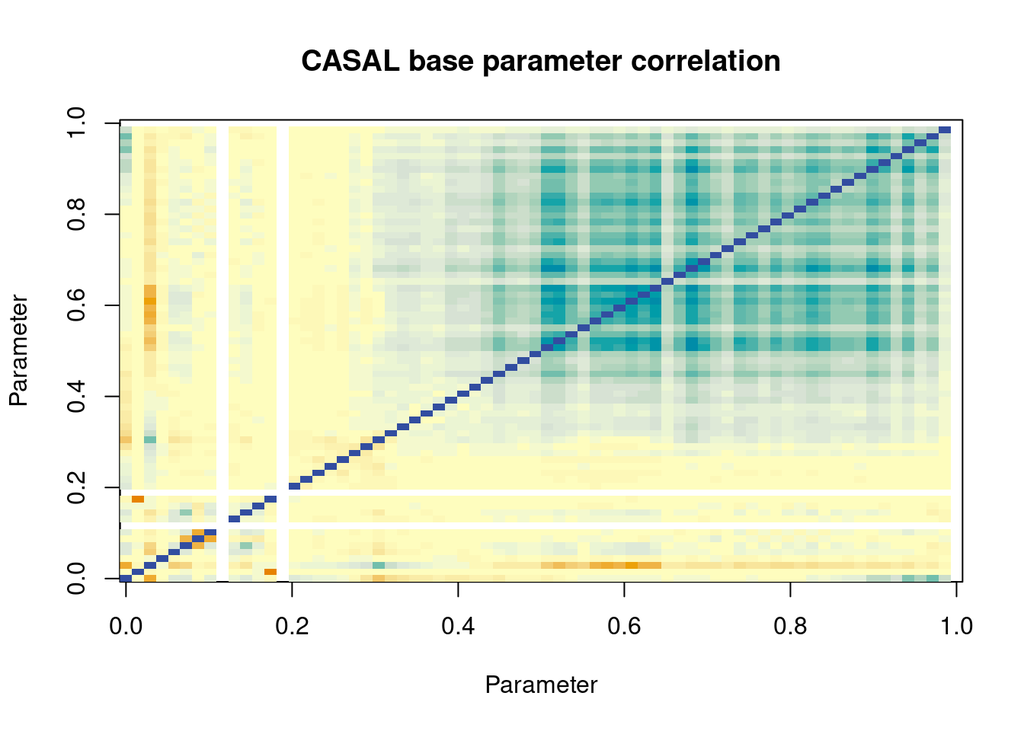

```
## [1] "CASAL base parameter correlation range (excluding 1.0): -0.5771 0.7601"
```

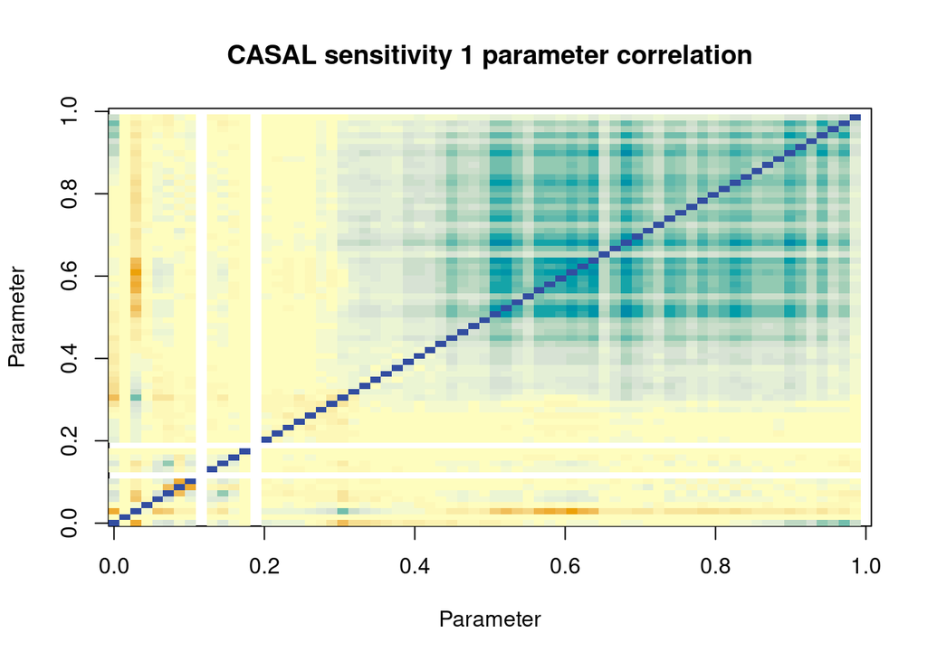

```
## [1] "CASAL sensitivity 1 parameter correlation range (excluding 1.0): -0.465 0.7616"
```

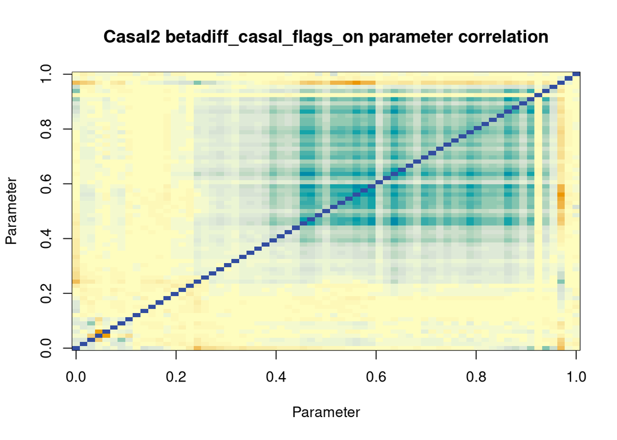

```
## [1] "Casal2 betadiff_casal_flags_on parameter correlation range (excluding 1.0): -0.496137678991627 0.754222111654299"
```

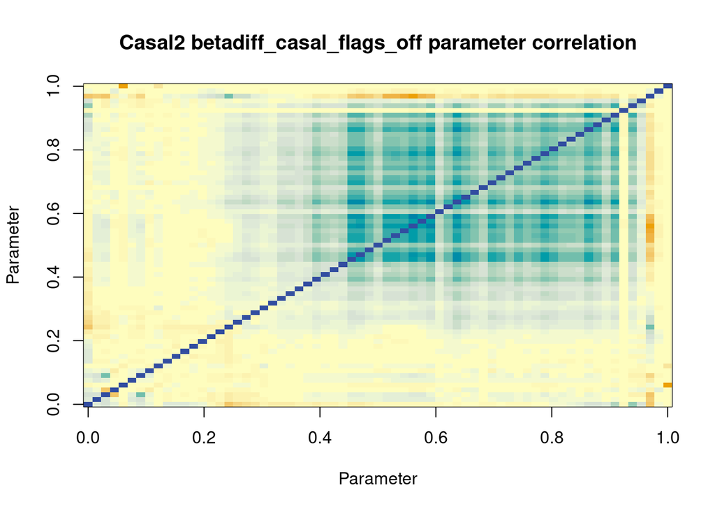

```
## [1] "Casal2 betadiff_casal_flags_off parameter correlation range (excluding 1.0): -0.477568420867415 0.766082936063558"
```

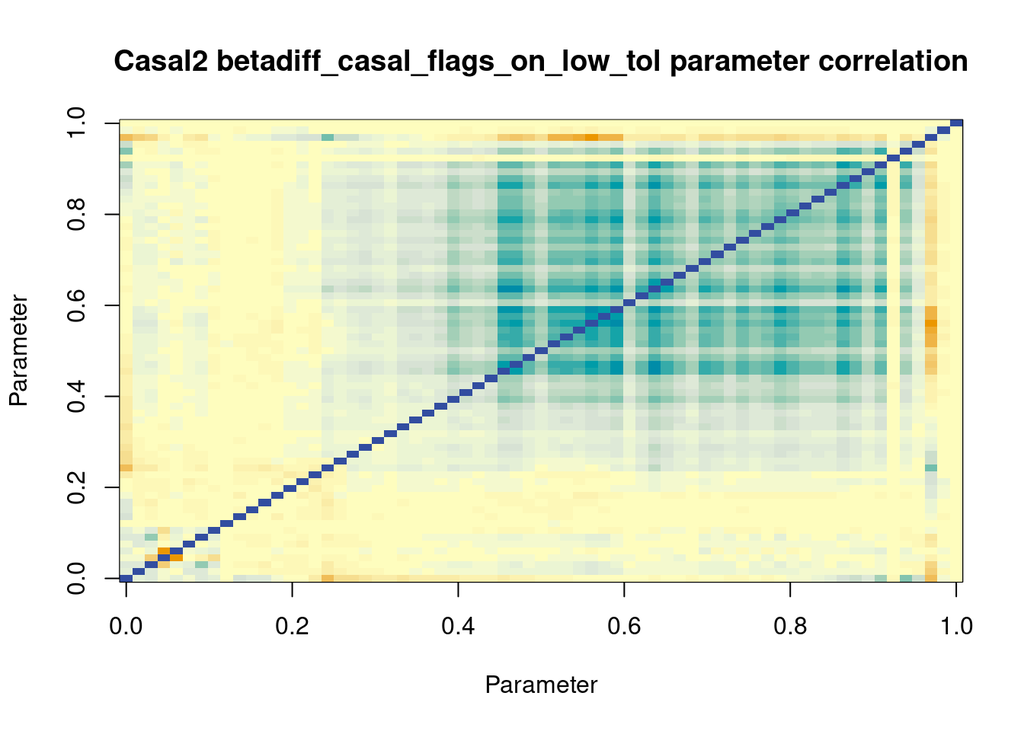

```
## [1] "Casal2 betadiff_casal_flags_on_low_tol parameter correlation range (excluding 1.0): -0.494542407877019 0.753488756509326"
```

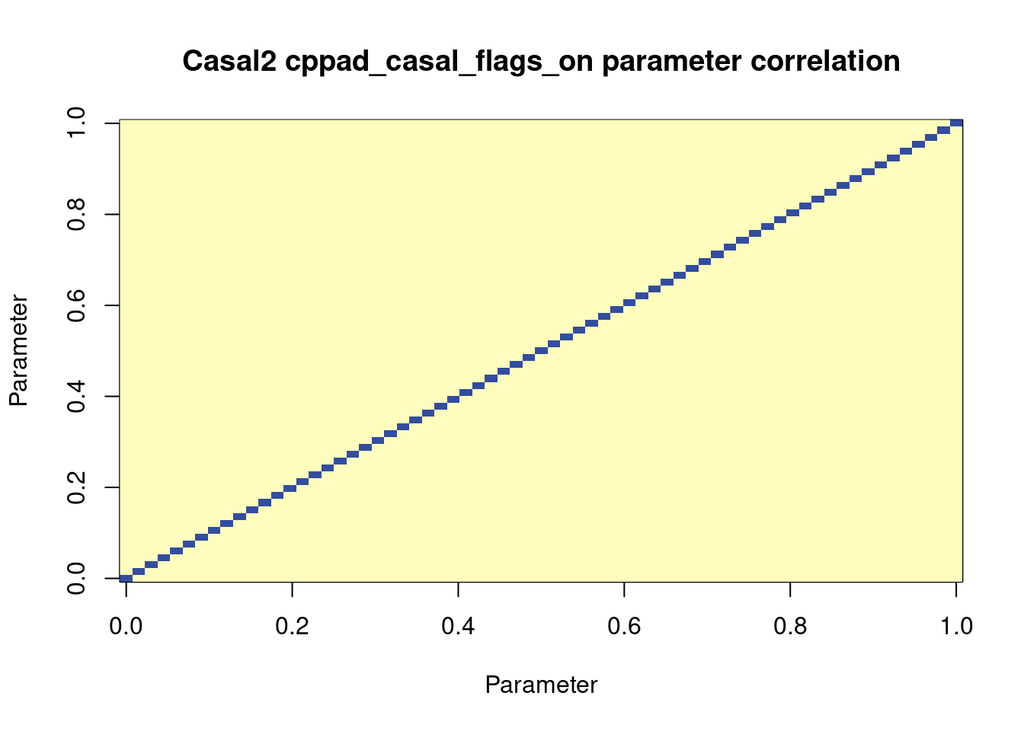

```
## [1] "Casal2 cppad_casal_flags_on parameter correlation range (excluding 1.0): 0 0"
```

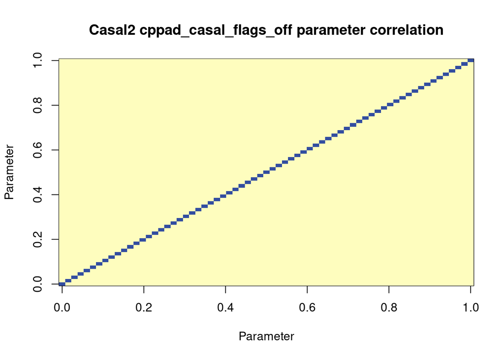

```
## [1] "Casal2 cppad_casal_flags_off parameter correlation range (excluding 1.0): 0 0"
```

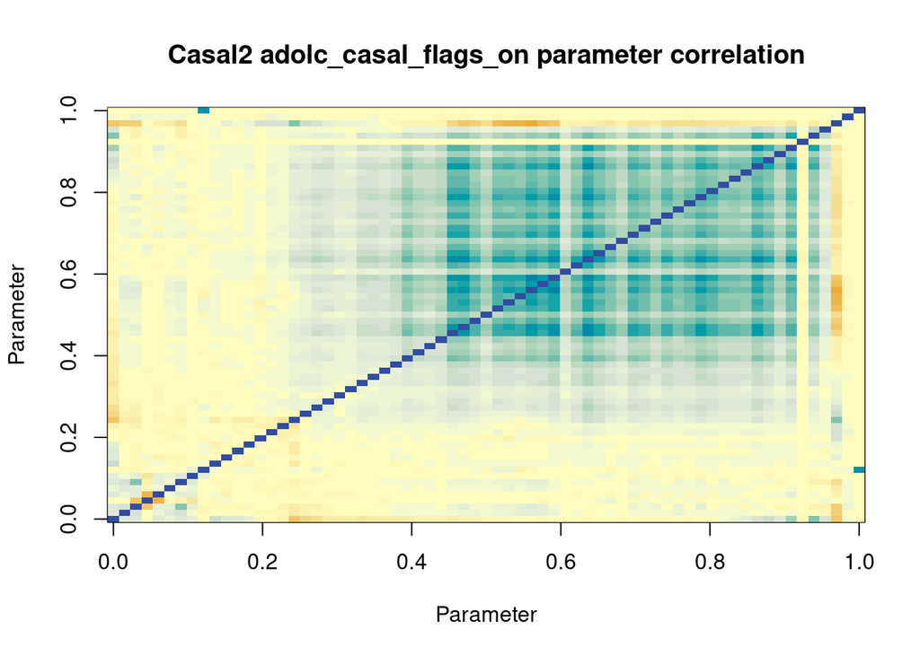

```
## [1] "Casal2 adolc_casal_flags_on parameter correlation range (excluding 1.0): -0.449867451595697 0.765859852647084"
```

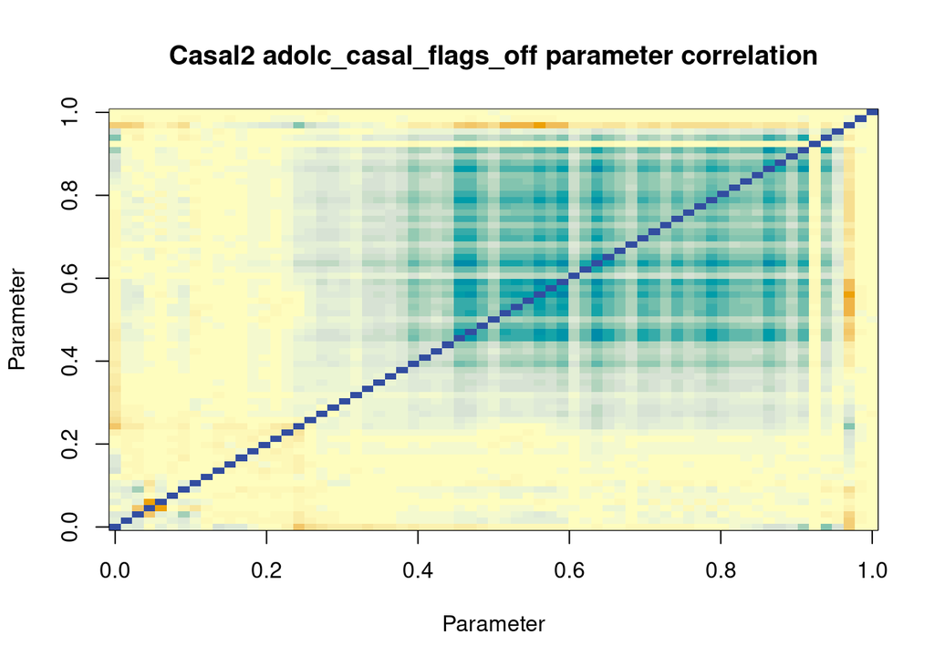

```
## [1] "Casal2 adolc_casal_flags_off parameter correlation range (excluding 1.0): -0.475954909278459 0.77245952551618"
```

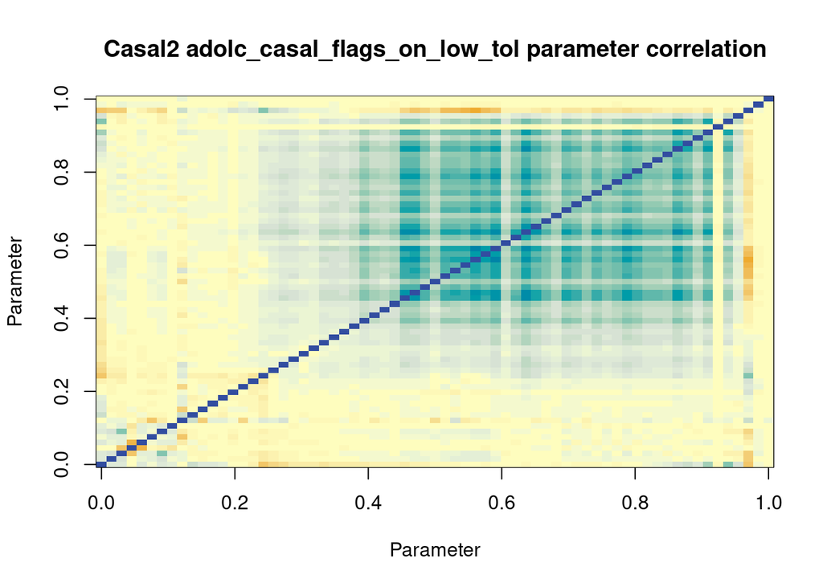

```
## [1] "Casal2 adolc_casal_flags_on_low_tol parameter correlation range (excluding 1.0): -0.450174071110356 0.76519971244179"
```

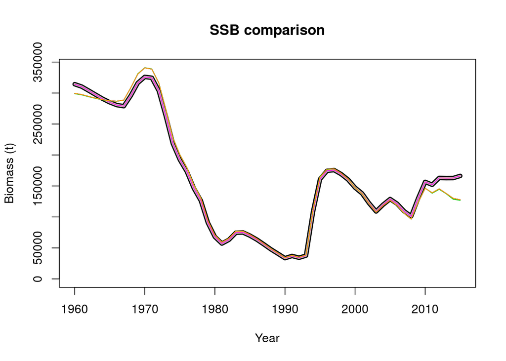

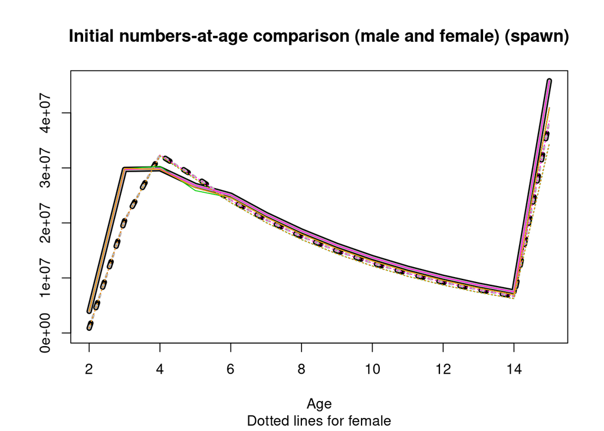

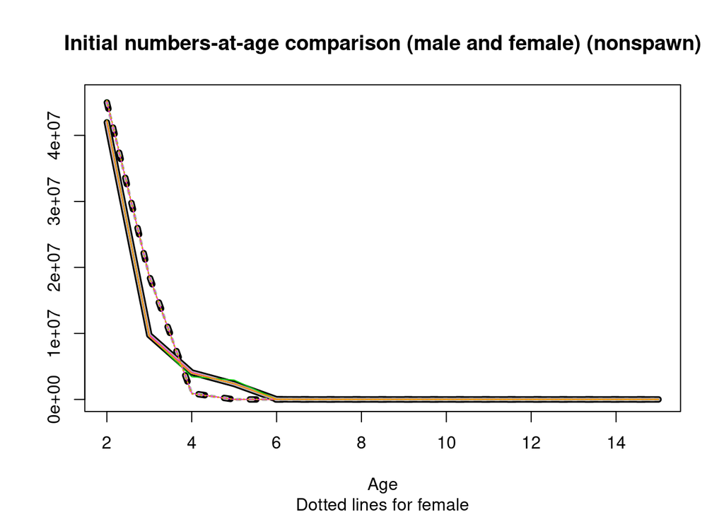

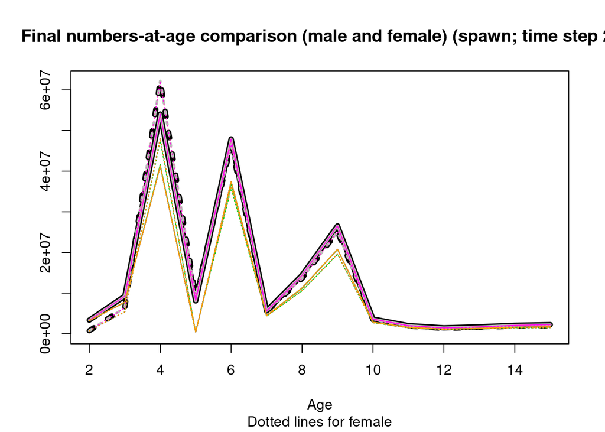

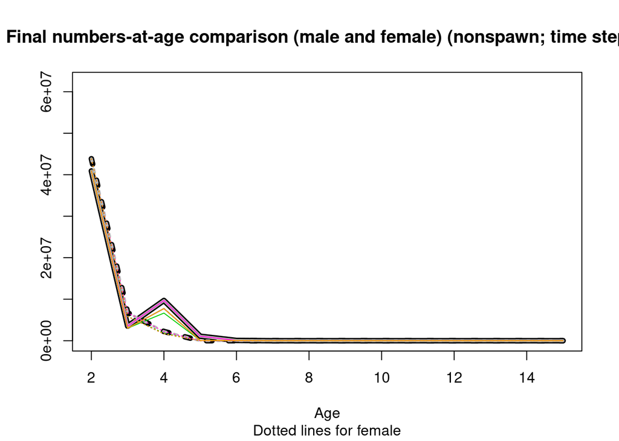

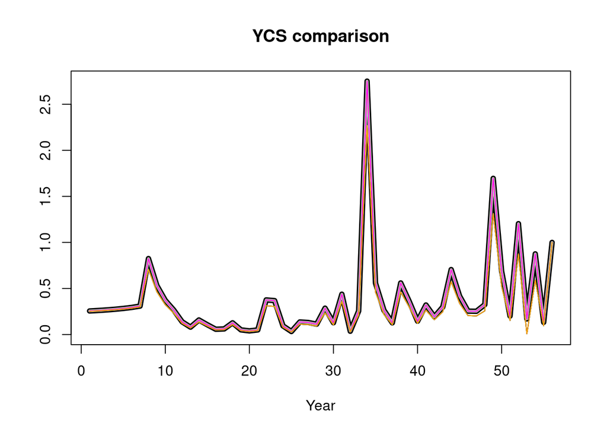

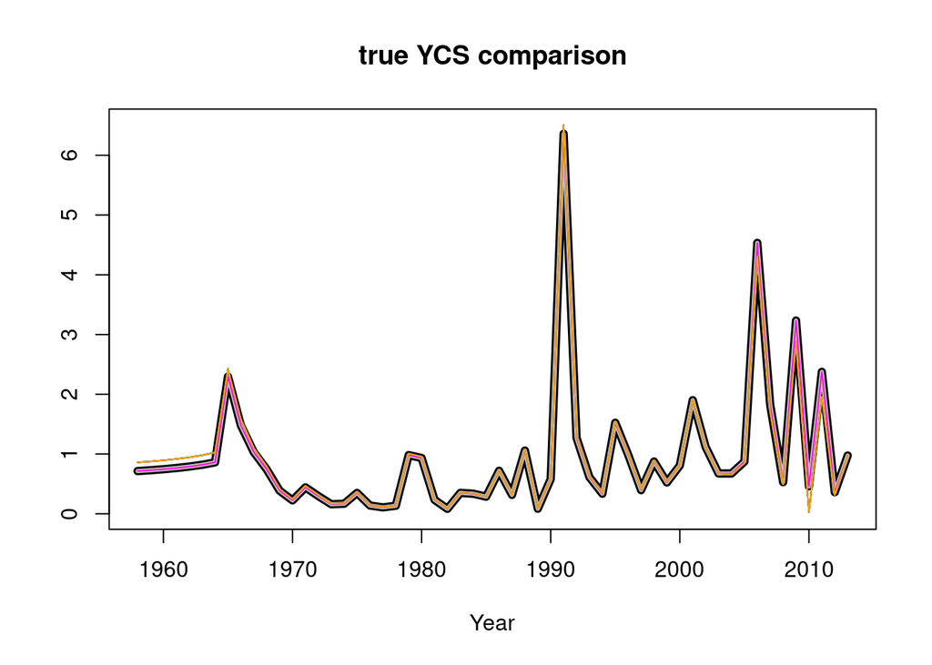

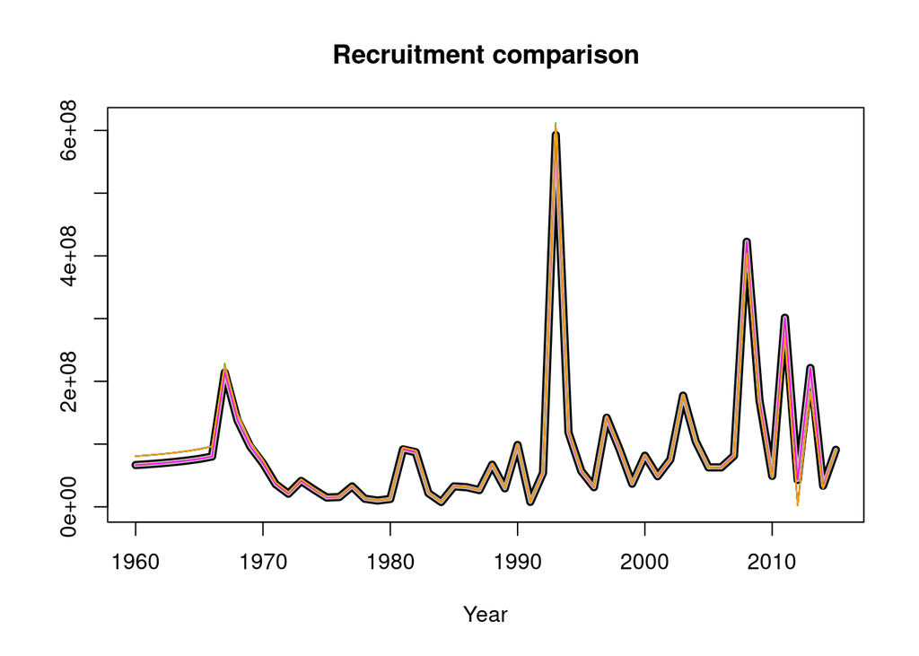

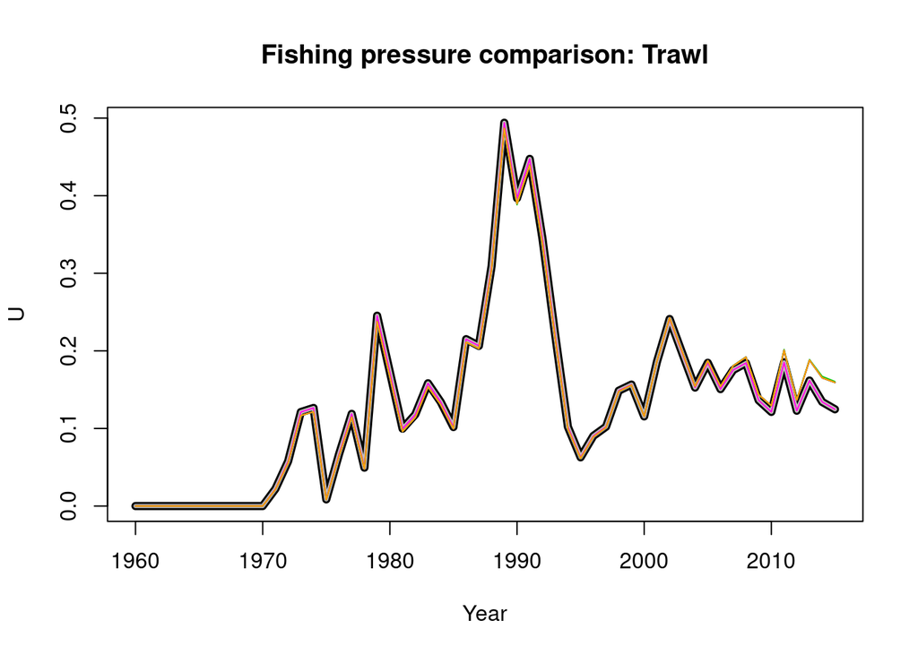

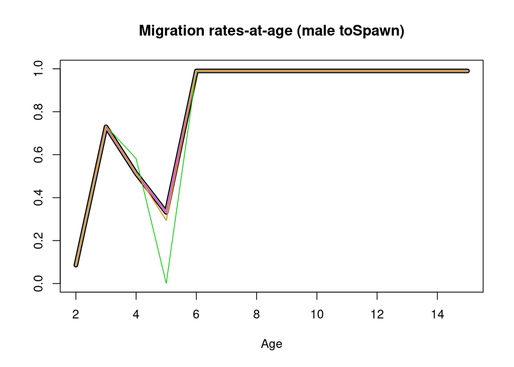

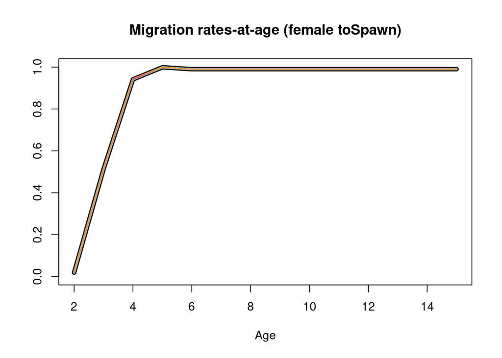